# Ant diversity patterns across tropical elevation gradients: effects of sampling method and subcommunity - Longino - 2019 - Ecosphere - Wiley Online Library

[figure not shown]

Article

Open Access

# Ant diversity patterns across tropical elevation gradients: effects of sampling method and subcommunity

[John T. Longino](https://esajournals.onlinelibrary.wiley.com/action/doSearch?ContribAuthorStored=Longino%2C+John+T)

[Michael G. Branstetter](https://esajournals.onlinelibrary.wiley.com/action/doSearch?ContribAuthorStored=Branstetter%2C+Michael+G)

[Philip S. Ward](https://esajournals.onlinelibrary.wiley.com/action/doSearch?ContribAuthorStored=Ward%2C+Philip+S)

First published: 01 August 2019

https://doi.org/10.1002/ecs2.2798

Corresponding Editor: Robert R. Parmenter.

## Abstract

Local diversity may be influenced by niche assembly processes involving competition for limited resources, or by niche conservatism and the length of time clades have had to diversify. Mid‐elevation peaks in ant diversity on wet forest elevational gradients are most consistent with niche conservatism effects. However, it is possible that subsets of the ant community vary in the degree to which niche assembly processes are important, and this may be revealed by sampling methods that bias toward particular subsets. A previous study of ant‐elevation patterns in Middle American wet forest relied on Winkler sampling, a method that samples much of the ant community that occurs in leaf litter and rotten wood on the forest floor. Here, we evaluate richness patterns at the same sites as the previous study, using two alternative methods: baiting and beating. Baiting attracts ants to a concentrated resource and might be expected to attract a community more shaped by competitive interactions. Diversity patterns at baits were nearly identical to patterns from Winkler samples, for all ants combined and for the genus *Pheidole*, which are abundant omnivorous ants that are among the most common at baits. There was no evidence that stronger competitive effects influenced the shape of the diversity curve. Beating samples capture ants that forage on low vegetation, a distinct arboreal community with lower phylogenetic diversity than litter ants and inhabiting a more variable microclimate. Arboreal ants differed from litter ants in having a less distinct mid‐elevation peak, with less of a decline from 500 m to sea level. The lowland decline in litter ant diversity may be caused by the recent upslope shift in temperature associated with the current interglacial period. Arboreal ants may be buffered from this effect by adaptation to canopy life, tolerating broader extremes of temperature, or by high rates of dispersal from warmer regions.

## Introduction

The drive to explain large‐scale patterns of biotic diversity has motivated centuries of research that has yielded both more detailed descriptions of patterns and improved understanding of the causes (Rosenzweig 1995). The two environmental gradients that have received the most attention are latitude and elevation. Elevational gradients are of interest because they are replicated across space and have pronounced environmental changes over short distances (Rahbek 1995, Graham et al. 2014). Popular taxa for studying macroecological patterns in the terrestrial realm include vertebrates, vascular plants, and a few groups of insects. Among the insects, ants are a prominent group because of their ubiquity and high biomass (Hölldobler and Wilson 1990, Wilson and Hölldobler 2005). Ants on elevational gradients have been the subject of numerous studies (e.g., Olson 1994, Fisher 1996, 1998, 1999a, Sanders 2002, Sanders et al. 2007, Malsch et al. 2008, Longino and Colwell 2011, Machac et al. 2011, Longino et al. 2014, Smith et al. 2014, Szewczyk and McCain 2016, 2019, Liu et al. 2018, Longino and Branstetter 2019), revealing a variety of patterns and suggested causes.

Tropical mountains in areas of abundant and weakly seasonal precipitation are particularly interesting because they reduce seasonality and moisture as factors, leaving temperature as the dominant factor characterizing the gradient. In wet forests of Middle America, ant occupancy (presence or absence in small sampling units) is nearly 100% from sea level to ~2000 m elevation, above which ant‐free patches begin to appear (reflected in samples with no ants) (Longino and Colwell 2011, Longino et al. 2014). By 3000 m, ants are almost entirely absent. Ant abundance, measured as average number of individuals per m<sup>2</sup>, is also relatively stable from sea level to ~1500 m, above which it sharply declines (Longino and Colwell 2011, Longino et al. 2014). Diversity is quite different, showing a truncated bell curve, rising to a peak around 500 m, and then declining. This pattern occurs not only on individual elevational gradients (Olson 1994, Longino and Colwell 2011), but also appears to be robust throughout Middle America, from southern Mexico to Costa Rica (Longino and Branstetter 2019).

A suite of hypotheses to explain local diversity rely on species interactions and niche partitioning, and these often contain various forms of temperature dependence (Pianka 1966, Currie 1991, Kaspari et al. 2000, 2004, Hawkins et al. 2003). High temperatures may permit higher energy flux through organisms, which allows more ways to divide the energy and still maintain viable population densities (Allen et al. 2002, Brown et al. 2004). Available energy for consumers, such as ants, is based on ecosystem productivity. Barring moisture limitation (McCain 2007), productivity is thought to increase monotonically with temperature (Brown et al. 2004). Net primary productivity (NPP), on the other hand, is more difficult to predict or measure (Clark et al. 2001) and in tropical wet forests may actually be a step function with high NPP in lowland forests and low NPP in montane forests (Cleveland et al. 2011). However, these hypotheses have not been successful at predicting the mid‐elevation diversity peaks seen in many studies of ants on elevational gradients (e.g., Longino and Branstetter 2019, Szewczyk and McCain 2019).

Other hypotheses are based on evolutionary history and niche conservatism and do not necessarily require niche partitioning or competitive interactions (Webb et al. 2002, Wiens and Donoghue 2004). In these hypotheses, richness peaks reflect the original niche of the common ancestor of a clade and the niche within which the clade has had the longest time to diversify. These concepts are related to the midpoint attractor model of Colwell et al. (2016), in which species cluster near a favored region of a gradient. The midpoint attractor model successfully predicted mid‐elevation diversity peaks in ants and other taxa (Colwell et al. 2016). Longino and Branstetter (2019) proposed niche conservatism to explain the truncated bell curve of ant diversity in Middle American elevational gradients. The generally higher diversity in the lowlands compared to cloud forest habitats reflected the early origin of ants in lowland rainforests (Brady et al. 2006, Moreau and Bell 2013), but the peak around 500 m and decline below that resulted from relatively recent lowland biotic attrition following interglacial warming (Colwell et al. 2008). In an exemplary study of ant diversity on elevational gradients in the Rocky Mountains of Colorado, Szewczyk and McCain (2019) used a hierarchical Bayesian occupancy model to assess the effects of multiple hypothesized explanatory variables on species richness. They found mid‐elevation diversity peaks on all transects. In spite of the high environmental complexity of this temperate region, with large habitat variation and strong seasonality, the temperature envelopes of individual species emerged as the dominant factor determining the number of species at a site. They invoked niche conservatism as the best explanation.

Previous elevation studies of Middle American wet forest ants (Olson 1994, Longino and Colwell 2011, Longino et al. 2014, Longino and Branstetter 2019) have mostly been based on a single sampling method: microarthropod extraction from 1‐m<sup>2</sup> patches of forest floor leaf litter and rotten wood (the miniWinkler method, Fisher 1999b). MiniWinkler sampling takes 1 m<sup>2</sup> of the forest floor litter and rotting wood, shakes it up, and lets all the ants fall out. It is a snapshot of ants in a small area at a point in time. There is relatively little role for ant behavior, and it samples a wide variety of trophic guilds: generalized omnivores, predators, and fungus growers. Two other sampling methods, baiting and beating, sample ants in interestingly contrasting ways. With baiting, ants are attracted to a concentrated resource. There are discovery and recruitment to a point source where competition is paramount (Adler et al. 2007). There are direct aggressive interactions and displacements. With beating, low vegetation is sampled by sweeping with a net or beating low vegetation over a sheet. Like Winkler sampling, it does not create a competitive arena but simply samples ants occurring in a volume of vegetation. The difference is that beating is sampling a phylogenetically distinctive community. Ground ants and arboreal ants are highly segregated, with the latter being dominated by a few highly derived arboreal lineages (Wilson and Hölldobler 2005, Nelsen et al. 2018).

Considering ant diversity patterns, baiting and beating results might diverge from Winkler results in several ways. For baiting samples, if direct competition for food is more important for ants attracted to baits compared to other litter‐dwelling ants, the predictions of niche partitioning might hold. Ant diversity at baits will be related to productivity or temperature, both of which decline monotonically with elevation. Thus, ant diversity will also decline monotonically, with no mid‐elevation peak. An alternative mechanism that still rests on competition and niche partitioning could potentially produce the opposite result, with a mid‐elevation peak but even steeper lowland decline. Higher temperatures at low elevations might increase dominance at baits by a few competitively dominant species. In other words, temperature effects on behavioral competition at baits might be nonlinear, such that the negative effects of competition override the positive effects of productivity only at the lowest elevations. But if niche conservatism is the primary factor, regardless of sampling method or level of competition, we expect the elevational diversity pattern at baits to closely match the pattern for the litter community as a whole.

For beating samples, which do not rely on attraction to a resource, there is no expectation of a shift toward patterns reflecting greater niche partitioning. But within the niche conservatism paradigm, there may still be differences from the elevational pattern seen in litter ants. Arboreal habitats exhibit greater temperature extremes compared to the litter and rotten wood of the forest floor, and arboreal ants are more heat tolerant than ground ants (Kaspari et al. 2015). This could broaden the temperature envelopes of arboreal species, lessening the effect of recent interglacial temperature change and reducing lowland biotic attrition.

The large inventory projects in Middle America that generated the miniWinkler data reported in Longino and Branstetter (2019) and earlier studies also included replicated baiting and beating samples. Here, we examine patterns of ant occupancy and diversity as a function of elevation for these samples, comparing the results with the miniWinkler studies. The results continue to support niche conservatism as the primary mechanism generating elevational patterns in montane ants.

## Methods

### Sites and sampling methods

Data from 54 sites are reported here, 51 of which are the same sites reported in Longino and Branstetter (2019). Sampling occurred over 15 yr, with sites distributed from central Costa Rica to Veracruz, Mexico, a span of 11° latitude (9–20° N), and ranging from 20 to 2600 m elevation (Appendix S1: Table S1). The results reported here are from multiple projects, from 2001 to 2016. Sites include 5 from the Barva Transect in Costa Rica (Project ALAS, Longino and Colwell 2011); 33 from Chiapas, Mexico, to Nicaragua (Project LLAMA, Longino et al. 2014); and 8 from sites in Costa Rica and 8 in the states of Oaxaca and Veracruz, Mexico (Project ADMAC, Longino and Branstetter 2019). Sites were subjectively chosen to be closed‐canopy evergreen forest in areas with abundant rainfall. Sites varied in land‐use history, ranging from decades‐old regenerating forest to mature old‐growth forest, and from sites deep within large reserves to small islands of forest in agricultural landscapes. In Costa Rica, lowland wet forest habitats are continuous with cloud forest habitats. From Nicaragua northward, wet forests in the Caribbean lowlands are often separated from island‐like mesophyll cloud forests by a matrix of pine forest or more xeric habitats.

Sampling of arboreal ants was carried out at 52 sites, using two methods: sweeping and beating. For the five ALAS sites in Costa Rica, sweep nets were used to sample low vegetation, mainly in clearings, treefall gaps, and trail edges, during clear weather. Net contents were periodically transferred to a large plastic bag. Each sample was one hour of sweeping activity by one person. After the hour of sweeping, the sample was returned to the laboratory and fumigated with ethyl acetate for one hour. Ants were then picked from the sample and stored in 95% ethanol. For LLAMA and ADMAC projects, beating sheets were used. Low vegetation inside forest, along forest margins, and in treefall gaps was beat over a 1‐m<sup>2</sup> sheet, and falling ants were collected into a vial with aspirator and forceps. Each sample was two hours of sampling activity by one person. Average richness of sweep samples was slightly lower than beating samples, but the elevational pattern was similar for both methods, and omitting the five sites with sweep samples did not alter the conclusions. Sweep samples and beating samples are treated equally in analyses and are all referred to as beating samples in the rest of the paper.

Ant workers were removed from each sample and identified, with identifications being to species for most groups, but to genus for certain groups that are difficult to sort to species. Details of taxa and taxon selection are in Appendix S1. All collection codes, occurrence data, and a taxon list are in Data S1.

### Analysis

For each baiting transect, occupancy was the proportion of baits at which ants occurred (out of 20 total), dominance was the proportion of baits occupied by the most frequent species, and richness was the total number of species observed in the transect. For each site, transect‐level variables were mean dominance, mean occupancy, and mean richness (with *n = n*umber of transects). For each beating sample, incidence data (presence–absence) were recorded. For each site, beating sample‐level variables were occupancy (the proportion of beating samples that contained ants) and mean richness. For both baiting and beating samples, site‐level richness was examined using interpolation or extrapolation of richness to a common coverage of 0.80, using incidence frequencies (i.e., the number of transects or beating samples in which a species occurred; Colwell et al. 2012, Chao and Jost 2012, Chao et al. 2014). Calculations were carried out with iNEXT (Hsieh et al. 2016) in R version 3.4.3. For baiting samples, two datasets were analyzed, the entire ant dataset and a data partition containing only the genus *Pheidole*. *Pheidole* are among the most common ants at baits and show high levels of recruitment and competitive interactions. For beating samples, two datasets were analyzed, the entire dataset and a data partition containing only arboreal species (Data S1), which excluded ground‐nesting species whose workers forage in the arboreal stratum.

To examine the relationship between dependent variables and elevation, which is used here as a proxy for temperature, each was modeled as linear, quadratic, and cubic functions of elevation. Model performance was evaluated by comparing Akaike information criterion (AIC<sub>c</sub>) values, using R version 3.4.3, and the package AICcmodavg (R Core Team 2017). The occurrence of a mid‐elevation peak was supported if a cubic model was favored over linear or quadratic models.

## Results

Occupancy patterns were similar for baiting and beating samples (Fig. 1). Quadratic and cubic models of occupancy as a function of elevation were similarly supported, and both were significantly better than linear models (Table 1). Dominance at baits showed the same pattern as occupancy, and the two variables were correlated (correlation coefficient 0.87). Dominance results are not reported further. Baiting and beating showed high occupancy (at or near 100%) from sea level to ~1000 m, followed by an abrupt drop. Occupancy of miniWinkler samples is similar, but remains high at higher elevations, beginning to drop ~2000 m (Longino et al. 2014).

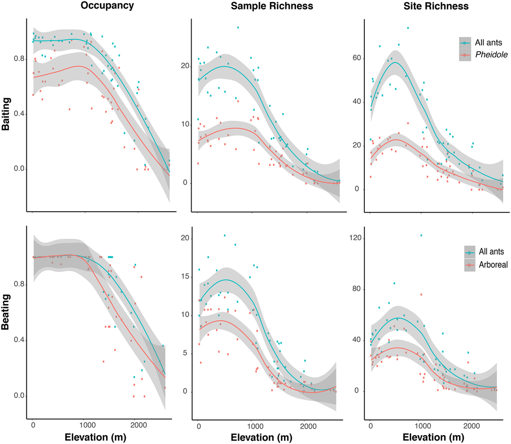

**Figure 1**

Ant occupancy and richness as a function of elevation in Middle American wet forests. Baiting results are upper panels; beating results are lower panels. Occupancy is the proportion of baits (within a transect) or beating samples (within a site) that contained ants. Sample richness is mean number of species per transect (baiting) or sample (beating). Site richness is interpolated or extrapolated richness at sample coverage 0.80. Smoothed curves are LOESS fits (R, ggplot2).

Table 1. Regression models of occupancy, sample richness, and site richness as a function of elevation for baiting and beating samples

| Data set | Variable | Model | ∆AIC<sub>c</sub> | *r* <sup>2</sup> | Maximum |
| --- | --- | --- | --- | --- | --- |
| Baits, all ants | Occupancy | Cubic | 2.47 | 0.83 |  |
|  |  | Quadratic | 0.00 | 0.83 |  |
|  |  | Linear | 37.14 | 0.63 |  |
|  | Sample richness | Cubic | 0.00 | 0.80 | 20.3 at 430 m |
|  |  | Quadratic | 11.07 | 0.75 |  |
|  |  | Linear | 12.95 | 0.73 |  |
|  | Site richness | Cubic | 0.00 | 0.75 | 52.2 at 450 m |
|  |  | Quadratic | 15.20 | 0.65 |  |
|  |  | Linear | 14.14 | 0.65 |  |
| Baits, *Pheidole* | Occupancy | Cubic | 0.57 | 0.64 |  |
|  |  | Quadratic | 0.00 | 0.63 |  |
|  |  | Linear | 16.85 | 0.47 |  |
|  | Sample richness | Cubic | 0.00 | 0.69 | 9.6 at 540 m |
|  |  | Quadratic | 10.17 | 0.61 |  |
|  |  | Linear | 15.70 | 0.55 |  |
|  | Site richness | Cubic | 0.00 | 0.66 | 20.90 at 510 m |
|  |  | Quadratic | 9.54 | 0.58 |  |
|  |  | Linear | 11.11 | 0.56 |  |
| Beating, all ants | Occupancy | Cubic | 2.23 | 0.68 |  |
|  |  | Quadratic | 0.00 | 0.69 |  |
|  |  | Linear | 23.91 | 0.49 |  |
|  | Sample richness | Cubic | 0.00 | 0.77 | 14.5 at 410 m |
|  |  | Quadratic | 13.44 | 0.69 |  |
|  |  | Linear | 12.04 | 0.69 |  |
|  | Site richness | Cubic | 0.00 | 0.54 | 55.2 at 530 m |
|  |  | Quadratic | 6.75 | 0.46 |  |
|  |  | Linear | 6.59 | 0.44 |  |
| Beating, arboreal | Occupancy | Cubic | 0.82 | 0.64 |  |
|  |  | Quadratic | 0.00 | 0.64 |  |
|  |  | Linear | 7.58 | 0.57 |  |
|  | Sample richness | Cubic | 0.00 | 0.74 | 9.5 at 230 m |
|  |  | Quadratic | 7.22 | 0.69 |  |
|  |  | Linear | 6.05 | 0.69 |  |
|  | Site richness | Cubic | 0.00 | 0.49 | 32.97 at 480 m |
|  |  | Quadratic | 4.81 | 0.42 |  |
|  |  | Linear | 2.82 | 0.43 |  |

### Notes

- Baiting samples are analyzed for all ants and for the genus *Pheidole*. Beating samples are analyzed for all ants and for arboreal lineages (see *Methods*). Linear, quadratic, and cubic models are compared. Models are evaluated by ∆AIC<sub>c</sub> values, comparing the best model (lowest AIC<sub>c</sub>) to the other models. Low values indicate higher support, and models with ∆AIC<sub>c</sub> < 4 are equally well supported. Support for a cubic model is evidence of a mid‐elevation peak. Maximum is the predicted maximum value of the variable for the cubic model and the elevation at which it occurs. *n* = 49 sites for baiting; 52 sites for beating.

Sample richness patterns were also similar for the two methods. Cubic models of richness as a function of elevation are better supported than either quadratic or linear models, for both baiting and beating samples (Table 1). Both baiting and beating samples show bell‐shaped richness curves peaking at 430 m and 410 m elevation, respectively (Fig. 1). Site richness patterns for baiting and beating parallel sample richness patterns, with statistically supported peaks at 450 m and 530 m, respectively. These results are very similar to the results for litter sampling (peak richness at 418 m elevation; Longino and Branstetter 2019).

Baiting results for *Pheidole* alone were very similar to the results for all ants, but with lower *r*<sup>2</sup> values (Table 1, Fig. 1). Occupancy starts to drop ~1000 m, and both sample and site richness have significant mid‐elevation peaks at 540 m and 510 m, respectively, somewhat higher than for all ants and for miniWinkler samples.

## Discussion

Closed‐canopy wet forests of Middle America are home to a diverse set of ant species, each of which has a particular nesting and foraging behavior. Sampling methods vary in how efficiently they capture the available species, with particular methods favoring particular microhabitats and behaviors (Longino and Colwell 1997). Winkler sampling efficiently captures the fauna of litter and rotten wood, irrespective of foraging behavior. Winkler sampling of the litter community has shown, first of all, that occupancy, the presence of ants in sampling units, is uniformly high from sea level to ~2000 m, above which it drops steeply as ant‐free patches begin to appear. The relationship between diversity and elevation is a truncated bell curve, rising from sea level to about 500 m elevation and then dropping steeply to near absence at 2500 m (Longino and Branstetter 2019). Two other sampling methods, baiting and beating, sample in very different ways, targeting different subsets of the ant community. We asked whether these methods show the same patterns or differ in ways predicted by alternative hypotheses.

Baiting attracts omnivorous ground ants to a concentrated resource, creating small arenas of intense competitive interactions. In contrast, Winkler samples contain species with a broader array of feeding behaviors, including generalist and specialist predators, fungus growers, and cryptic ants whose feeding behaviors are unknown. We would expect communities sampled by baiting to show more effects of competition than communities sampled by Winkler sampling. If there is competition‐driven niche partitioning of available energy or productivity (Allen et al. 2002, Brown et al. 2004), we expect diversity to decline with elevation, with no mid‐elevation peak (Kaspari et al. 2000, 2004, Hawkins et al. 2003). An alternative hypothesis is that higher temperatures increase behavioral dominance and intensify competitive interactions in a nonlinear way, disproportionately countering effects of increased energy availability or productivity at low elevation, such that the combination causes a mid‐elevation diversity peak. We found that the diversity curve for baiting samples was nearly identical to the curve for Winkler sampling, and there was no pattern of increased dominance at low elevations. The occupancy and dominance patterns were similar, with high and uniform bait occupancy to ~1000 m, above which it steeply declined. The results for the genus *Pheidole* alone were the same. *Pheidole* is the most diverse ant genus in the Neotropics. Nearly all species are generalist omnivores with strong recruitment systems, and they are among the most abundant ants at baits. For *Pheidole*, effects of competition should be paramount, yet their diversity curve was similar to the curve for Winkler samples.

Beating samples are composed of ants that forage in the low arboreal zone. The sampled community is a mix of ground‐nesting ants that also forage in low vegetation, and purely arboreal species that are rarely found on the ground. Thus, communities sampled by beating and Winkler sampling are partially overlapping. We found that when all ants in beating samples were examined, the diversity curve was similar to the Winkler curve. However, when arboreal ants were analyzed separately, the mid‐elevation diversity peak was less pronounced. Arboreal ant diversity remained relatively high throughout the lowlands. On the one hand, this follows the prediction of a productivity‐based niche partitioning, with productivity being uniformly high across a range of lowland elevations (Cleveland et al. 2011), and competition structuring the assembly of arboreal ant communities. However, niche conservatism is an alternative, and more likely, explanation.

Niche conservatism posits that climate niche evolves slowly and that clades have highest diversity in the ancestral climate niche (Webb et al. 2002, Wiens and Donoghue 2004, Wiens et al. 2007). With niche conservatism, local species diversity may be determined by the available pool of species for a given climate regime, rather than by competitive interactions. Niche conservatism has been invoked to explain mid‐elevation peaks in ant diversity (Longino and Branstetter 2019, Szewczyk and McCain 2019). The lowland decline, in particular, has been explained as a result of the current interglacial period. During much of the Pleistocene, over million‐year time scales, temperature profiles and vegetation zones on elevational gradients in Middle America were ~500 m lower than they are today (Bush et al. 2009, Grauel et al. 2016). Current climates below 500 m are thus anomalously warm for many Middle American ant species, and highest ant diversity clusters around 500 m. Arboreal species, however, may be more tolerant of temperature extremes, as a result of their life in the canopy, exposed to full tropical sun (Kaspari et al. 2015). Much like temperate zone species that must tolerate a much broader range of temperature fluctuations and thus have broader climate envelopes (Janzen 1967), tropical arboreal species may be less affected by the anomalous warming at the low end of their elevational ranges. Another possibility is that arboreal species have greater dispersal rates, on average, than leaf litter inhabitants, and thus better abilities to recolonize newly warm (post‐glacial) habitats. This assumes a warm equatorial refuge somewhere.

In general, the strong congruence of elevational patterns, independent of sampling method or ant subcommunity, favors explanations based on long‐term, macroevolutionary processes that influence regional species pools. Further light could be shed on these processes by examining the ages and phylogenetic relationships of ant species on elevational gradients, and how rapidly the climate niche evolves.

## Acknowledgments

We thank the dozens of staff and collaborators in the ALAS, TEAM, LLAMA, and ADMAC projects. We thank the many agency staff, reserve managers, and community supporters at our field sites. Two anonymous reviewers significantly improved the manuscript. This work was supported by multiple grants from the U.S. National Science Foundation, the National Geographic Society, and Conservation International, over a 25‐yr period. Most recent support is NSF DEB‐1354739 (Project ADMAC) and National Geographic Society Committee for Research and Exploration Grant 9568‐14. USDA is an equal opportunity provider and employer.

[figure not shown]

August 2019

e02798

### Details

  © 2019 The Authors.

  This is an open access article under the terms of the[Creative Commons Attribution](http://creativecommons.org/licenses/by/3.0/) License, which permits use, distribution and reproduction in any medium, provided the original work is properly cited.

[figure not shown]

### Keywords

  - [elevational gradient](https://esajournals.onlinelibrary.wiley.com/action/doSearch?field1=Keyword&text1=elevational%20gradient)
  - Formicidae
  - macroecology
  - [niche conservatism](https://esajournals.onlinelibrary.wiley.com/action/doSearch?field1=Keyword&text1=niche%20conservatism)

### Funding Information

  - National Geographic Society
  - Conservation International
  - U.S. National Science Foundation. Grant Number: DEB‐1354739
  - National Geographic Society Committee for Research and Exploration. Grant Number: 9568‐14